# Homework 4

Anyesha Ray

February 26, 2020

```r
data(ChickWeight, package="datasets")
#?ChickWeight
library("ggplot2")
library("dplyr")
library("datasets")
```

## Get a frequency breakdown of the number of chicks, their average weight and the standard deviation of the weights in each of the diets at the start of the study. Store the resulting data frame in a variable named weight0 and print.

```r
q1 <- ChickWeight %>% filter(Time == 0)
weight0 <- ChickWeight %>% group_by(Diet) %>% summarize(num_chicks = n(), avg_weight= mean(weight), sd_weight= sd(weight))
weight0
```

```
## # A tibble: 4 x 4
##   Diet  num_chicks avg_weight sd_weight
##   <fct>      <int>      <dbl>     <dbl>
## 1 1            220       103.      56.7
## 2 2            120       123.      71.6
## 3 3            120       143.      86.5
## 4 4            118       135.      68.8
```

## Each chick should have twelve weight measurements. Use the dplyr package to identify how many measurements are there for each chick. Extract a subset of the data for all chicks with complete information, name the data set complete, and print the first 3 rows.

```r
complete <- ChickWeight %>% group_by(Chick) %>% mutate(count = n()) %>% filter(count == 12)
complete[1:3,]
```

```
## # A tibble: 3 x 5
## # Groups:   Chick [1]
##   weight  Time Chick Diet  count
##    <dbl> <dbl> <ord> <fct> <int>
## 1     42     0 1     1        12
## 2     51     2 1     1        12
## 3     59     4 1     1        12
```

## In the complete data set introduce a new variable that measures the current weight difference compared to day 0. Name this variable weightgain and print the first 3 rows of the new data frame.

```r
weight_gain_1 <- complete %>% group_by(Chick) %>% filter(Time == 0)
complete$initial_weight <- rep(weight_gain_1$weight, each=12)
complete <- complete %>% mutate(weightgain = weight - initial_weight)
complete[1:3,]
```

```
## # A tibble: 3 x 7
## # Groups:   Chick [1]
##   weight  Time Chick Diet  count initial_weight weightgain
##    <dbl> <dbl> <ord> <fct> <int>          <dbl>      <dbl>
## 1     42     0 1     1        12             42          0
## 2     51     2 1     1        12             42          9
## 3     59     4 1     1        12             42         17
```

## Use {ggplot2} to create side-by-side boxplots of weightgain by Diet for day 21. Change the order of the categories in the Diet variable such that the boxplots are ordered by median weightgain, and the lower limit of the y axis should be 0. Describe the relationship in 2-3 sentences.

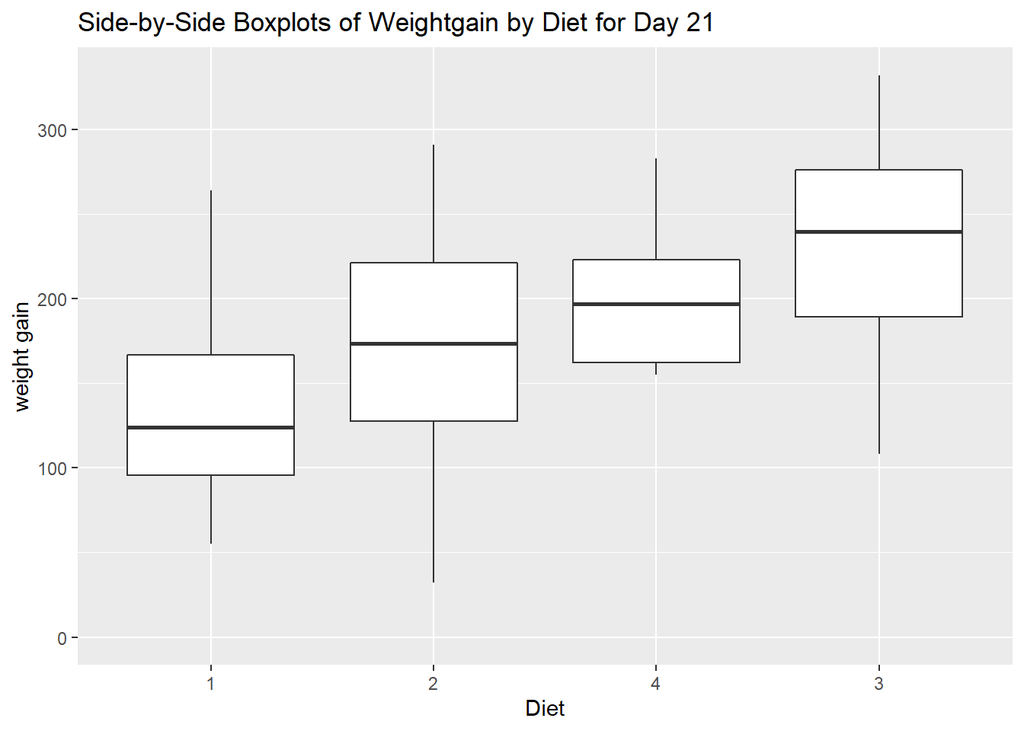

```r
complete$Diet <- factor(complete$Diet, levels(complete$Diet)[c(1,2,4,3)])
complete %>% filter(Time == 21) %>% ggplot(aes(x= Diet, y= weightgain)) + geom_boxplot() + expand_limits(y=0) + labs(y = 'weight gain', title = 'Side-by-Side Boxplots of Weightgain by Diet for Day 21')
```

## Answer each of the following questions using numerical and graphical summary. Also explain what you found: (a) Which chick gained the most weight and which gained the least weight? (b) What diets were they on?

```r
num5 <- complete %>% filter(Time == 21)
maxweight <- max(num5$weightgain)
minweight <- min(num5$weightgain)
num5 %>% filter(weightgain == maxweight | weightgain == minweight)
```

```
## # A tibble: 2 x 7
## # Groups:   Chick [2]
##   weight  Time Chick Diet  count initial_weight weightgain
##    <dbl> <dbl> <ord> <fct> <int>          <dbl>      <dbl>
## 1     74    21 24    2        12             42         32
## 2    373    21 35    3        12             41        332
```

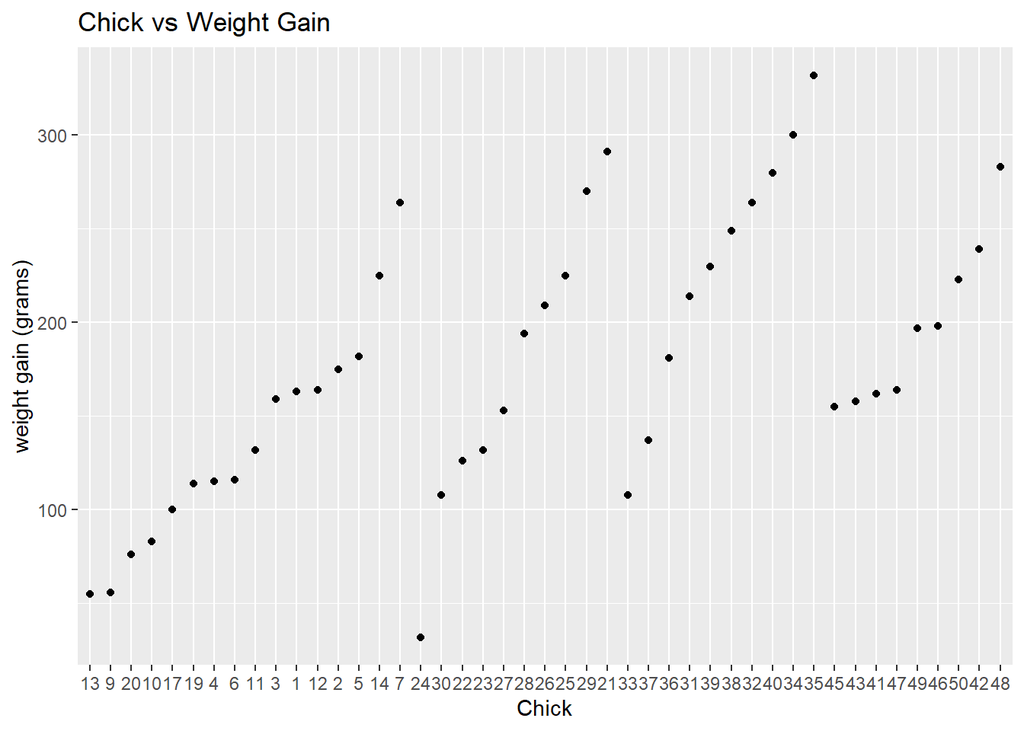

```r
num5 %>% ggplot(aes(x=Chick, y=weightgain)) + geom_point() + labs(y='weight gain (grams)', title='Chick vs Weight Gain')
```

[output not shown]

## For the chicks with the least and the most weight at time 0, plot their growth trajectories over time.

```r
min <- min(complete$initial_weight)
max <- max(complete$initial_weight)
complete %>% filter(Time == 0 & (initial_weight==min | initial_weight == max))
```

```
## # A tibble: 10 x 7
## # Groups:   Chick [10]
##    weight  Time Chick Diet  count initial_weight weightgain
##     <dbl> <dbl> <ord> <fct> <int>          <dbl>      <dbl>
##  1     43     0 3     1        12             43          0
##  2     43     0 11    1        12             43          0
##  3     43     0 19    1        12             43          0
##  4     43     0 23    2        12             43          0
##  5     39     0 27    2        12             39          0
##  6     39     0 28    2        12             39          0
##  7     39     0 29    2        12             39          0
##  8     39     0 33    3        12             39          0
##  9     39     0 36    3        12             39          0
## 10     39     0 48    4        12             39          0
```

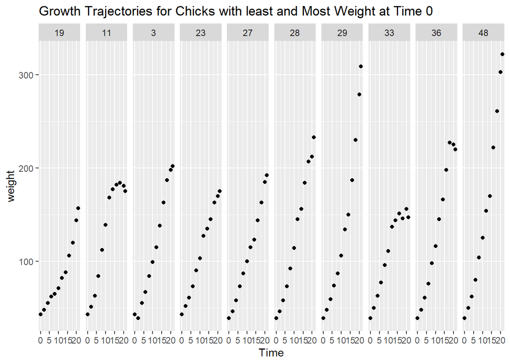

```r
complete %>%filter(Chick == 3 | Chick == 11 | Chick == 19 | Chick == 23 | Chick == 27 | Chick == 28 | Chick == 29 | Chick == 33 | Chick == 36 | Chick == 48)  %>% ggplot(aes(x=Time,y=weight)) + geom_point() + facet_grid(cols = vars(Chick)) + labs(title='Growth Trajectories for Chicks with least and Most Weight at Time 0')
```

## Add to the previous plot the average growth trajectory for all chicks (calculated as the mean weight for each chick at each time). How do the trajectories compare?

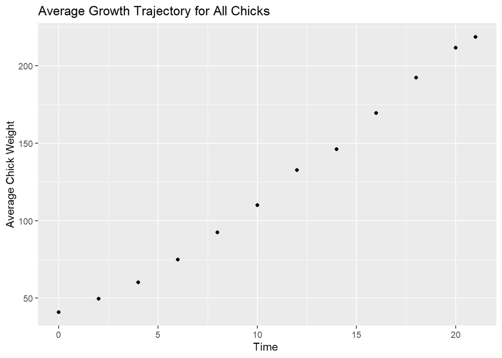

```r
avgtraj <- complete %>% group_by(Time) %>% summarize(avgw = mean(weight))
avgtraj %>% ggplot(aes(x=Time,y=avgw)) + geom_point() + labs(y='Average Chick Weight', x='Time ',title='Average Growth Trajectory for All Chicks')
```

The average trajectory for all chicks does not decreases at any point. However for the individual chicks the graphs often decreased at a certain point.

## What else do you find interesting in the dataset? Show your exploratory analysis.

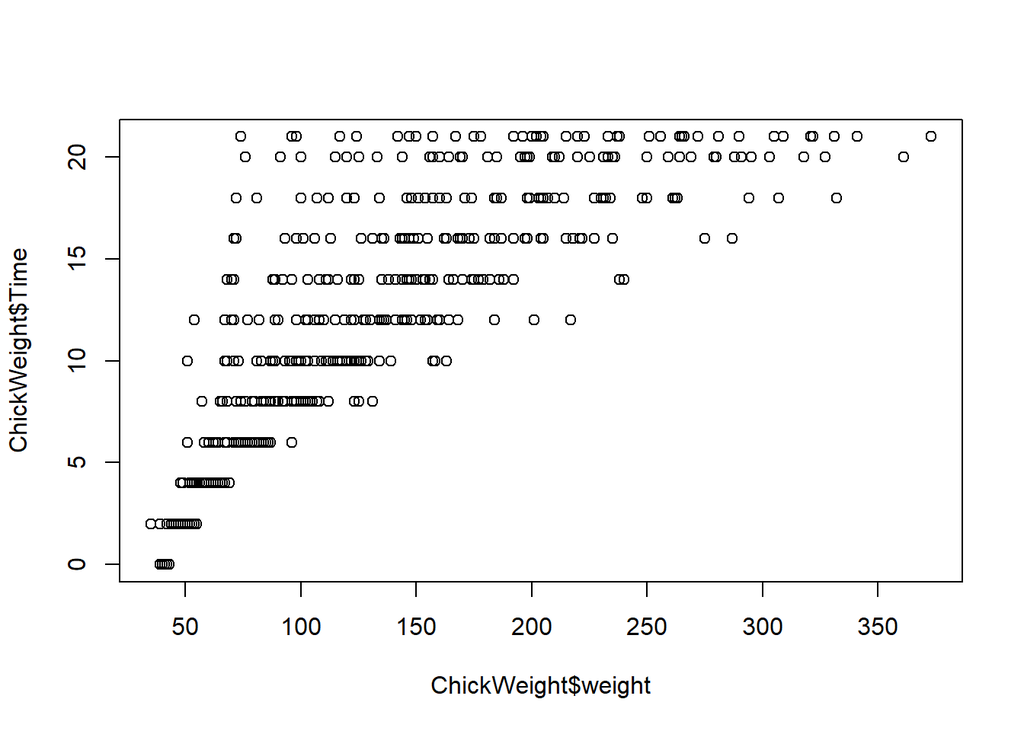

```r
scatter= plot(ChickWeight$weight, ChickWeight$Time)
```

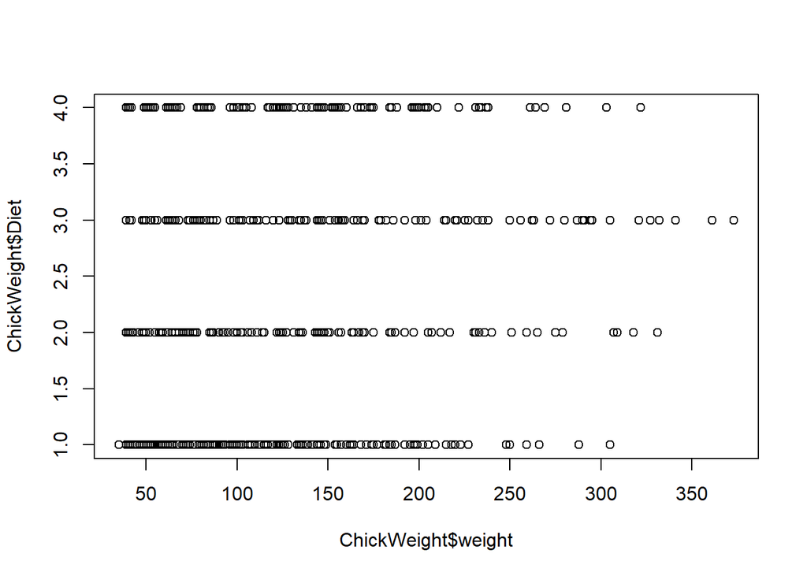

```r
scatter2= plot(ChickWeight$weight, ChickWeight$Diet)
```

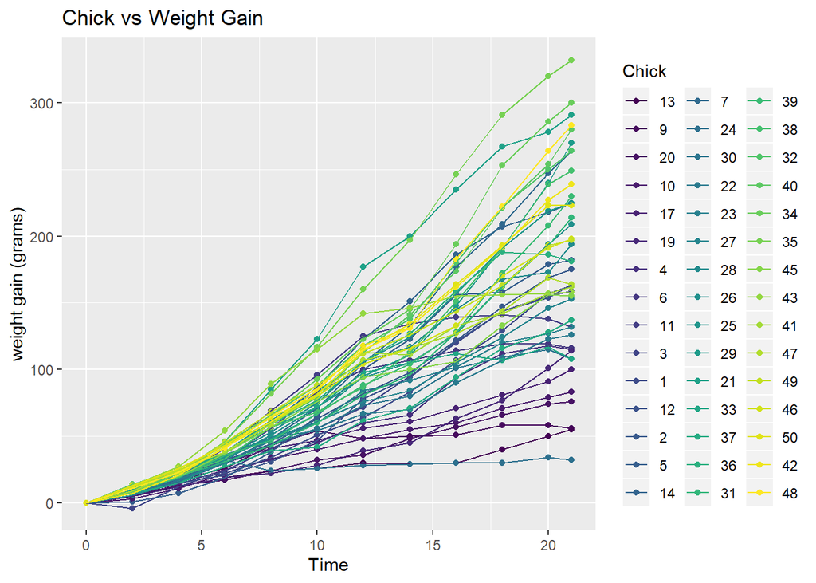

```r
complete %>% ggplot(aes(x=Time, y=weightgain)) + geom_point(aes(color=Chick)) + geom_line(aes(color=Chick)) + labs(y='weight gain (grams)', title='Chick vs Weight Gain')
```

One thing I thought was interesting to look at was the weight gain for all the chicks over time. We did a graphical summary for Day 21 but not for over time. It is interesting to see that there is a very clear distinction between which chicks didn’t have much growth and which ones did compared to the other chicks.